# Quiz 02

Week 03

Please place your name in the upper-right corner.

1. If you had a matrix in R called `dat` that had 10 rows and 8 columns, write how would you (1) index the fifth row, (2), the third column, and, take a guess, (3) the last five rows of the first column.
2. Fundamental to this course is understanding is understanding the difference between dynamic models and solutions to dynamic models. Please, in one or two sentences describe this difference. In addition, please write down the model and solution to the continuous-time density-independent equation (from last week’s reading, discussion, and lab).
3. Just using words (not math or graphs), briefly (a couple of sentence), describe (1) how the rate of change of population changes as a function of density and, then, (2) how the per-capita rate of changes as a function of density.
4. Stevens (2023) presented two versions of differential (i.e., continuous-time) equations equating the rate of change to a density-dependent process. In addition to the two equations, I will add a third. For all three of these equations that follow, (1) multiply their right-hand sides through, if needed, and (2) do the algebra to solve for $N$ when the rate of change is 0; i.e, $\mathrm{d}N/\mathrm{d}t = 0$. Note they are all quadratic (i.e., second-order polynomials), meaning that there are two values of $N$ for which you are solving for/isolating. Hint: $N = 0$ will be one for each, which should make biological sense to you.  
   $\frac{\mathrm{d}N}{\mathrm{d}t} = N\left(r - \alpha N\right)$  
   $\frac{\mathrm{d}N}{\mathrm{d}t} = rN\left(\frac{K - N}{K}\right)$  
   $\frac{\mathrm{d}N}{\mathrm{d}t} = rN\left(1 - \alpha N\right)$
5. It is instructional and useful to understand our dynamical models not only as rates of change of populations, but the per-capita rates of change. To find the per-capita rate of change, simply divide both sides of the equation by $N$. That’s it! Please make four graphs below. The first row should be the $r$-$K$ and the second should be the $r$-$\alpha$ logistic models, respectively equations 2 and 1 from question 4. For the first column, please plot population growth rate for each equation as a function of density; i.e., density on the horizontal axis and the population growth rate (i.e., the derivative) on the vertical axis. For the second column, please plot per-capita growth rate for each equation as a function of density; i.e., density on the horizontal axis and the per-capita growth rate (i.e., the derivative$/N$) on the vertical axis.
6. The highest estimated reproductive rate (i.e., intrinsic rate of increase) for brown bears (*Ursus arctos*) is 0.96 and the highest recorded density is 0.41 individuals per km$^2$. For every increase in brown bears density, how much does their per-capita growth rates decrease? What parameter does this value correspond to in the $r$-$\alpha$ logistic model (equation 1 from question 4)?

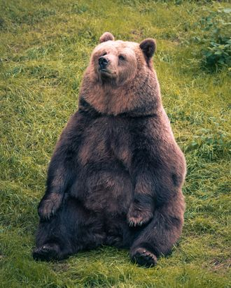

(So cute)